# IMDB | IST 652 FINAL PROJECT | ALI HO & KENDRA OSBURN

```python
#We want to get a total count for the number of percent_profit counts for each production company.
'''This shows that we have 2 indexes budget and percent_profit... We want to create columns from each index
We are creating a new column named budget by extracting the values from the first index (0) which is the budget
index'''
movies_discretized_count_df_q2["production_company"]=movies_discretized_count_df_q2.index.get_level_values(0)
#We are creating a new column named total_donations by extracting the values from the second index (1) which is total_donations
movies_discretized_count_df_q2["percent_profit_category"] = movies_discretized_count_df_q2.index.get_level_values(1)
#Checking to make sure it worked...
movies_discretized_count_df_q2
#It did!
```

| main_production_co | percent_profit | counts | production_company | percent_profit_category |
| --- | --- | --- | --- | --- |
| DW | negative | 1 | DW | negative |
| Disney | negative | 1 | Disney | negative |
|  | low | 3 | Disney | low |
|  | high | 2 | Disney | high |
|  | extremely_high | 2 | Disney | extremely_high |
| Fox | negative | 1 | Fox | negative |
|  | low | 4 | Fox | low |
|  | high | 3 | Fox | high |
|  | extremely_high | 3 | Fox | extremely_high |
| None | negative | 22 | None | negative |
|  | low | 17 | None | low |
|  | high | 13 | None | high |
|  | extremely_high | 14 | None | extremely_high |
| Paramount | negative | 2 | Paramount | negative |
|  | low | 4 | Paramount | low |
|  | high | 2 | Paramount | high |
|  | extremely_high | 1 | Paramount | extremely_high |
| Sony | negative | 1 | Sony | negative |
|  | low | 3 | Sony | low |
|  | high | 2 | Sony | high |
|  | extremely_high | 2 | Sony | extremely_high |
| Universal | negative | 1 | Universal | negative |
|  | low | 6 | Universal | low |
|  | high | 4 | Universal | high |
|  | extremely_high | 9 | Universal | extremely_high |
| WB | low | 2 | WB | low |
|  | high | 8 | WB | high |
|  | extremely_high | 3 | WB | extremely_high |

```python
#Now we want to remove the indexes so, we can create a new group by to get the sum of the counts for each group
#To do this we are using the reset_index(drop = True) This will drop our group by indexes and allow us to create a new one.
movies_discretized_count_df_q2 = movies_discretized_count_df_q2.reset_index(drop = True)
#Now we are getting the sum of each production company category.
production_company_discretized_count_df_q2 = movies_discretized_count_df_q2.groupby(["production_company"])["counts"].sum()
#Checking the results
production_company_discretized_count_df_q2
```

```
production_company
DW            1
Disney        8
Fox          11
None         66
Paramount     9
Sony          8
Universal    20
WB           13
Name: counts, dtype: int64
```

```python
'''We ultimately want a column that contains the total counts for each production company. We are going to create
a new column that replicates the production company called production_company_count and then we will use the replace function to
replace the 1s with their total count, the 2s with their total count... '''
#First, replicating the income level column in a column named budget_category_count
movies_discretized_count_df_q2["production_company_count"] = movies_discretized_count_df_q2["production_company"]
#Now replacing the income level with the total count for each income level
movies_discretized_count_df_q2["production_company_count"] = movies_discretized_count_df_q2["production_company_count"].replace(["DW"], 1)
movies_discretized_count_df_q2["production_company_count"] = movies_discretized_count_df_q2["production_company_count"].replace(["Disney"], 8)
movies_discretized_count_df_q2["production_company_count"] = movies_discretized_count_df_q2["production_company_count"].replace(["Fox"], 11)
movies_discretized_count_df_q2["production_company_count"] = movies_discretized_count_df_q2["production_company_count"].replace(["None"], 66)
movies_discretized_count_df_q2["production_company_count"] = movies_discretized_count_df_q2["production_company_count"].replace(["Paramount"], 9)
movies_discretized_count_df_q2["production_company_count"] = movies_discretized_count_df_q2["production_company_count"].replace(["Sony"], 8)
movies_discretized_count_df_q2["production_company_count"] = movies_discretized_count_df_q2["production_company_count"].replace(["Universal"], 20)
movies_discretized_count_df_q2["production_company_count"] = movies_discretized_count_df_q2["production_company_count"].replace(["WB"], 13)
movies_discretized_count_df_q2
```

|  | counts | production_company | percent_profit_category | production_company_count |
| --- | --- | --- | --- | --- |
| 0 | 1 | DW | negative | 1 |
| 1 | 1 | Disney | negative | 8 |
| 2 | 3 | Disney | low | 8 |
| 3 | 2 | Disney | high | 8 |
| 4 | 2 | Disney | extremely_high | 8 |
| 5 | 1 | Fox | negative | 11 |
| 6 | 4 | Fox | low | 11 |
| 7 | 3 | Fox | high | 11 |
| 8 | 3 | Fox | extremely_high | 11 |
| 9 | 22 | None | negative | 66 |
| 10 | 17 | None | low | 66 |
| 11 | 13 | None | high | 66 |
| 12 | 14 | None | extremely_high | 66 |
| 13 | 2 | Paramount | negative | 9 |
| 14 | 4 | Paramount | low | 9 |
| 15 | 2 | Paramount | high | 9 |
| 16 | 1 | Paramount | extremely_high | 9 |
| 17 | 1 | Sony | negative | 8 |
| 18 | 3 | Sony | low | 8 |
| 19 | 2 | Sony | high | 8 |
| 20 | 2 | Sony | extremely_high | 8 |
| 21 | 1 | Universal | negative | 20 |
| 22 | 6 | Universal | low | 20 |
| 23 | 4 | Universal | high | 20 |
| 24 | 9 | Universal | extremely_high | 20 |
| 25 | 2 | WB | low | 13 |
| 26 | 8 | WB | high | 13 |
| 27 | 3 | WB | extremely_high | 13 |

```python
#Okay, we are one step closer... Now, we need to create a column that takes the counts/budget_category_counts * 100
movies_discretized_count_df_q2["percent"] = movies_discretized_count_df_q2["counts"]/movies_discretized_count_df_q2["production_company_count"] *100
#Looking at our data frame... It worked!!!
movies_discretized_count_df_q2.head()
```

|  | counts | production_company | percent_profit_category | production_company_count | percent |
| --- | --- | --- | --- | --- | --- |
| 0 | 1 | DW | negative | 1 | 100.0 |
| 1 | 1 | Disney | negative | 8 | 12.5 |
| 2 | 3 | Disney | low | 8 | 37.5 |
| 3 | 2 | Disney | high | 8 | 25.0 |
| 4 | 2 | Disney | extremely_high | 8 | 25.0 |

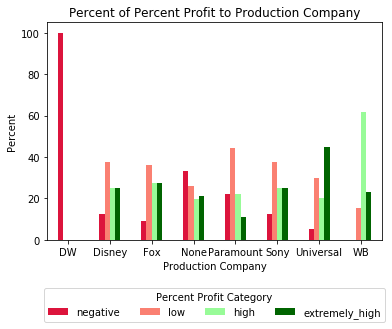

```python
#We no longer need the count columns
movies_discretized_count_df_q2.drop(["counts", "production_company_count"], axis = 1, inplace = True )
'''Attempting to graph this data using a grouped bar chart:
formula: df.pivot(columns, group, values).plot(kind = "type of graph", color = ["color to use, can be a list of colors"],
title = "you can set the title of your graph here")'''
graph = movies_discretized_count_df_q2.pivot("production_company", "percent_profit_category",
                                                "percent").plot(kind="bar", color = ["crimson", "salmon", "palegreen", "darkgreen"],
                                                               title = "Percent of Percent Profit to Production Company")
#Changing the y label of our graph to Percent
plt.ylabel("Percent")
#Changing the x axis label of our graph to Budget Category
plt.xlabel("Production Company")
#Making it so the tick labels are not angled
plt.xticks(rotation = 0)
#How to change the tick labels (we ended up not needing this, but want to keep for future reference)
#plt.Axes.set_xticklabels(graph, labels = ['extremely low', 'low', 'high', 'extremely high'])
#moving the legend position to underneath the graph, also setting it to have 4 columns so the legend is in a
#straight single line and adding a legend title
plt.legend( loc = "lower center", bbox_to_anchor = (.5, -.4), ncol = 4, title = "Percent Profit Category")
```

This graph provides some insights, however, most of our movies have more than one main production company and only one production company is being shown. For example, DreamWorks and Universal had a movie named First Man and it was profitable. However, based on the way that we assigned a main production company, only Universal was given credit for that movie.

```python
# Question:
#Does time of the month the movie is released affect percent profit?
'''We want to compare the percent_profit level percentage make up for each time of month. To do this we need to
get the count for each time of month, the count for each percent_profit level by time of month company and then divide
the count of the percent_profit/count of time of month and multiply by 100. We have to do this for each
time of month and level of percent_profits.'''
movies_discretized_count_q3 = movies_discretized_df.groupby(["week", "percent_profit"])["week"].count()
'''Taking the output from the line above and converting it to a data frame. We are using pandas, which we important as pd.
First, we call the package we are using then the function from that package and then what we want to run the function on.
pd.function(item to use). We are using the DataFrame function from the pandas package on the series created by our group by'''
movies_discretized_count_df_q3 = pd.DataFrame(movies_discretized_count_q3)
#Checking to see what our df looks like.
movies_discretized_count_df_q3
#Changing the column name from week to counts
movies_discretized_count_df_q3.columns = ["counts"]
#Checking to see what our df looks like.
movies_discretized_count_df_q3.head()
```

| week | percent_profit | counts |
| --- | --- | --- |
| week_1 | negative | 5 |
|  | low | 13 |
|  | high | 5 |
|  | extremely_high | 14 |
| week_2 | negative | 5 |

```python
#We want to get a total count for the number of percent_profit counts for each week.
'''This shows that we have 2 indexes week and percent_profit... We want to create columns from each index
We are creating a new column named week by extracting the values from the first index (0) which is the week
index'''
movies_discretized_count_df_q3["week"]=movies_discretized_count_df_q3.index.get_level_values(0)
#We are creating a new column named total_donations by extracting the values from the second index (1) which is percent_profit
movies_discretized_count_df_q3["percent_profit_category"] = movies_discretized_count_df_q3.index.get_level_values(1)
#Checking to make sure it worked...
movies_discretized_count_df_q3
#It did!
```

| week | percent_profit | counts | week | percent_profit_category |
| --- | --- | --- | --- | --- |
| week_1 | negative | 5 | week_1 | negative |
|  | low | 13 | week_1 | low |
|  | high | 5 | week_1 | high |
|  | extremely_high | 14 | week_1 | extremely_high |
| week_2 | negative | 5 | week_2 | negative |
|  | low | 9 | week_2 | low |
|  | high | 13 | week_2 | high |
|  | extremely_high | 7 | week_2 | extremely_high |
| week_3 | negative | 9 | week_3 | negative |
|  | low | 10 | week_3 | low |
|  | high | 6 | week_3 | high |
|  | extremely_high | 8 | week_3 | extremely_high |
| week_4 | negative | 10 | week_4 | negative |
|  | low | 7 | week_4 | low |
|  | high | 10 | week_4 | high |
|  | extremely_high | 5 | week_4 | extremely_high |

```python
#Now we want to remove the indexes so, we can create a new group by to get the sum of the counts for each group
#To do this we are using the reset_index(drop = True) This will drop our group by indexes and allow us to create a new one.
movies_discretized_count_df_q3 = movies_discretized_count_df_q3.reset_index(drop = True)
# Now we are getting the sum of each production company category.
week_discretized_count_df_q3 = movies_discretized_count_df_q3.groupby(["week"])["counts"].sum()
#Checking the results
week_discretized_count_df_q3
```

```
week
week_1    37
week_2    34
week_3    33
week_4    32
Name: counts, dtype: int64
```

```python
'''We ultimately want a column that contains the total counts for each week. We are going to create
a new column that replicates the week called week_count and then we will use the replace function to
replace the 1s with their total count, the 2s with their total count... '''
#First, replicating the income level column in a column named budget_category_count
movies_discretized_count_df_q3["week_count"] = movies_discretized_count_df_q3["week"]
#Now replacing the income level with the total count for each income level
movies_discretized_count_df_q3["week_count"] = movies_discretized_count_df_q3["week_count"].replace(["week_1"], 37)
movies_discretized_count_df_q3["week_count"] = movies_discretized_count_df_q3["week_count"].replace(["week_2"], 34)
movies_discretized_count_df_q3["week_count"] = movies_discretized_count_df_q3["week_count"].replace(["week_3"], 33)
movies_discretized_count_df_q3["week_count"] = movies_discretized_count_df_q3["week_count"].replace(["week_4"], 32)
movies_discretized_count_df_q3.head()
```

|  | counts | week | percent_profit_category | week_count |
| --- | --- | --- | --- | --- |
| 0 | 5 | week_1 | negative | 37 |
| 1 | 13 | week_1 | low | 37 |
| 2 | 5 | week_1 | high | 37 |
| 3 | 14 | week_1 | extremely_high | 37 |
| 4 | 5 | week_2 | negative | 34 |

```python
#Okay, we are one step closer... Now, we need to create a column that takes the counts/week_count * 100
movies_discretized_count_df_q3["percent"] = movies_discretized_count_df_q3["counts"]/movies_discretized_count_df_q3["week_count"] *100
#Looking at our data frame... It worked!!!
movies_discretized_count_df_q3.head()
```

|  | counts | week | percent_profit_category | week_count | percent |
| --- | --- | --- | --- | --- | --- |
| 0 | 5 | week_1 | negative | 37 | 13.513514 |
| 1 | 13 | week_1 | low | 37 | 35.135135 |
| 2 | 5 | week_1 | high | 37 | 13.513514 |
| 3 | 14 | week_1 | extremely_high | 37 | 37.837838 |
| 4 | 5 | week_2 | negative | 34 | 14.705882 |

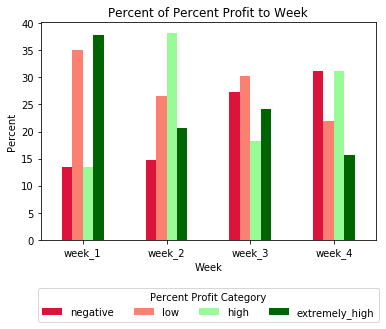

```python
#We no longer need the count columns
movies_discretized_count_df_q3.drop(["counts", "week_count"], axis = 1, inplace = True )
'''Attempting to graph this data using a grouped bar chart:
formula: df.pivot(columns, group, values).plot(kind = "type of graph", color = ["color to use, can be a list of colors"],
title = "you can set the title of your graph here")'''
graph = movies_discretized_count_df_q3.pivot("week", "percent_profit_category",
                                                "percent").plot(kind="bar", color = ["crimson", "salmon", "palegreen", "darkgreen"],
                                                               title = "Percent of Percent Profit to Week")
#Changing the y label of our graph to Percent
plt.ylabel("Percent")
#Changing the x axis label of our graph to Budget Category
plt.xlabel("Week")
#Making it so the tick labels are not angled
plt.xticks(rotation = 0)
#How to change the tick labels (we ended up not needing this, but want to keep for future reference)
#plt.Axes.set_xticklabels(graph, labels = ['extremely low', 'low', 'high', 'extremely high'])
#moving the legend position to underneath the graph, also setting it to have 4 columns so the legend is in a
#straight single line and adding a legend title
plt.legend( loc = "lower center", bbox_to_anchor = (.5, -.4), ncol = 4, title = "Percent Profit Category")
```

This is interesting in that it shows that movies released within the first two weeks of the month tend to be more profitable. We would like to look at a breakdown of month to percent profit for further analysis

```python
# Taking a brief detour back to our non-discretized df
movies_original_df.head()
```

[output not shown]

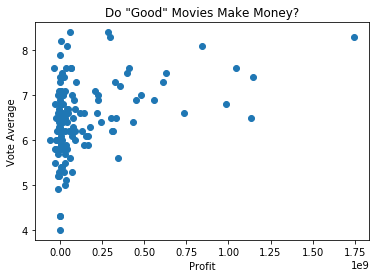

```python
# QUESTION: Do "Good" Movies Make Money? -- We're defining "Good" as vote average
plt.plot(movies_original_df.profit, movies_original_df.vote_average, 'o')
plt.title('Do "Good" Movies Make Money?')
plt.xlabel('Profit')
plt.ylabel('Vote Average')
plt.show()
```

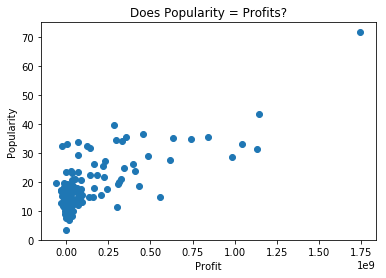

```python
# QUESTION: Does Popularity = Profit?
plt.plot(movies_original_df.profit, movies_original_df.popularity, 'o')
plt.title('Does Popularity = Profits?')
plt.xlabel('Profit')
plt.ylabel('Popularity')
plt.show()
```

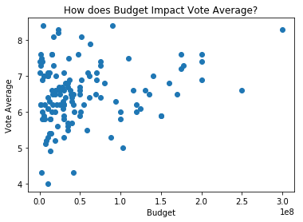

```python
# QUESTION: How does budget impact vote average?
plt.plot(movies_original_df.budget, movies_original_df.vote_average, 'o')
plt.title('How does Budget Impact Vote Average?')
plt.xlabel('Budget')
plt.ylabel('Vote Average')
plt.show()
```

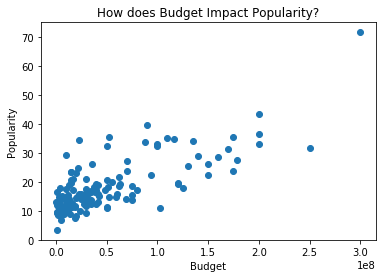

```python
# QUESTION: How does budget impact popularity?
plt.plot(movies_original_df.budget, movies_original_df.popularity, 'o')
plt.title('How does Budget Impact Popularity?')
plt.xlabel('Budget')
plt.ylabel('Popularity')
plt.show()
```

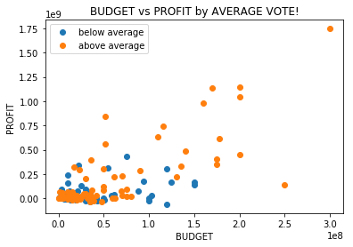

```python
# QUESTION: Is there a relationship between "Above Average Movies" and Budget/Price?
below_avg = movies_original_df[movies_original_df.vote_average < 6.5]
above_avg = movies_original_df[movies_original_df.vote_average >= 6.5]
plt.plot(below_avg.budget, below_avg.profit, 'o', label="below average")
plt.plot(above_avg.budget, above_avg.profit, 'o', label="above average")

plt.title('BUDGET vs PROFIT by AVERAGE VOTE!')
plt.xlabel('BUDGET')
plt.ylabel('PROFIT')
plt.legend()
plt.show()
```

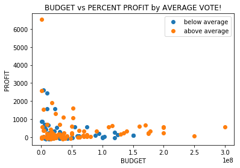

```python
# QUESTION: Is there a relationship between "Above Average Movies" and Budget/Price?
below_avg = movies_original_df[movies_original_df.vote_average < 6.5]
above_avg = movies_original_df[movies_original_df.vote_average >= 6.5]
plt.plot(below_avg.budget, below_avg.percent_profit, 'o', label="below average")
plt.plot(above_avg.budget, above_avg.percent_profit, 'o', label="above average")

plt.title('BUDGET vs PERCENT PROFIT by AVERAGE VOTE!')
plt.xlabel('BUDGET')
plt.ylabel('PROFIT')
plt.legend()
plt.show()
```

```python
# BIG QUESTION: What role do production companies play in the entertainment industry?
# Is there a relationship between production studio and average vote?
# Production studio and budget?
# Production studio and percent profit?
```

```python
# Adding the BIG EIGHT Production Studios to the DF

# WARNER BROS
wb = []
for movie in movies_original_df['production_companies']:
    if "Warner Bros" in movie:
        wb.append(True)
    else:
        wb.append(False)
movies_original_df['wb'] = wb

# MGM
mgm = []
for movie in movies_original_df['production_companies']:
    if "MGM" in movie:
        mgm.append(True)
    else:
        mgm.append(False)
movies_original_df['mgm'] = mgm

# DREAMWORKS
dw = []
for movie in movies_original_df['production_companies']:
    if "DreamWorks" in movie:
        dw.append(True)
    else:
        dw.append(False)
movies_original_df['dw'] = dw

# SONY
sony = []
for movie in movies_original_df['production_companies']:
    if "Sony" in movie:
        sony.append(True)
    else:
        sony.append(False)
movies_original_df['sony'] = sony

# DISNEY
disney = []
for movie in movies_original_df['production_companies']:
    if "Disney" in movie:
        disney.append(True)
    else:
        disney.append(False)
movies_original_df['disney'] = disney

#FOX
fox = []
for movie in movies_original_df['production_companies']:
    if "Century Fox" in movie:
        fox.append(True)
    else:
        fox.append(False)
movies_original_df['fox'] = fox

# PARAMOUNT
paramount = []
for movie in movies_original_df['production_companies']:
    if "Paramount" in movie:
        paramount.append(True)
    else:
        paramount.append(False)
movies_original_df['paramount'] = paramount

#UNIVERSAL
universal = []
for movie in movies_original_df['production_companies']:
    if "Universal" in movie:
        universal.append(True)
    else:
        universal.append(False)
movies_original_df['universal'] = universal
```

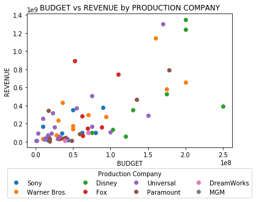

```python
sony = movies_original_df[movies_original_df.sony == True]
wb = movies_original_df[movies_original_df.wb == True]
disney = movies_original_df[movies_original_df.disney == True]
fox = movies_original_df[movies_original_df.fox == True]
universal = movies_original_df[movies_original_df.universal == True]
paramount = movies_original_df[movies_original_df.paramount == True]
dw = movies_original_df[movies_original_df.dw == True]
mgm = movies_original_df[movies_original_df.mgm == True]

plt.plot(sony.budget, sony.revenue, 'o', label="Sony")
plt.plot(wb.budget, wb.revenue, 'o', label="Warner Bros.")
plt.plot(disney.budget, disney.revenue, 'o', label="Disney")
plt.plot(fox.budget, fox.revenue, 'o', label="Fox")
plt.plot(universal.budget, universal.revenue, 'o', label="Universal")
plt.plot(paramount.budget, paramount.revenue, 'o', label="Paramount")
plt.plot(dw.budget, dw.revenue, 'o', label="DreamWorks")
plt.plot(mgm.budget, mgm.revenue, 'o', label="MGM")

plt.title('BUDGET vs REVENUE by PRODUCTION COMPANY')
plt.xlabel('BUDGET')
plt.ylabel('REVENUE')
plt.legend( loc = "lower center", bbox_to_anchor = (.5, -.4), ncol = 4, title = "Production Company")
plt.show()
```

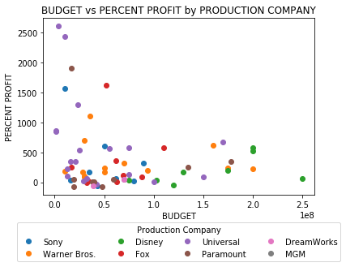

```python
sony = movies_original_df[movies_original_df.sony == True]
wb = movies_original_df[movies_original_df.wb == True]
disney = movies_original_df[movies_original_df.disney == True]
fox = movies_original_df[movies_original_df.fox == True]
universal = movies_original_df[movies_original_df.universal == True]
paramount = movies_original_df[movies_original_df.paramount == True]
dw = movies_original_df[movies_original_df.dw == True]
mgm = movies_original_df[movies_original_df.mgm == True]

plt.plot(sony.budget, sony.percent_profit, 'o', label="Sony")
plt.plot(wb.budget, wb.percent_profit, 'o', label="Warner Bros.")
plt.plot(disney.budget, disney.percent_profit, 'o', label="Disney")
plt.plot(fox.budget, fox.percent_profit, 'o', label="Fox")
plt.plot(universal.budget, universal.percent_profit, 'o', label="Universal")
plt.plot(paramount.budget, paramount.percent_profit, 'o', label="Paramount")
plt.plot(dw.budget, dw.percent_profit, 'o', label="DreamWorks")
plt.plot(mgm.budget, mgm.percent_profit, 'o', label="MGM")

plt.title('BUDGET vs PERCENT PROFIT by PRODUCTION COMPANY')
plt.xlabel('BUDGET')
plt.ylabel('PERCENT PROFIT')
plt.legend( loc = "lower center", bbox_to_anchor = (.5, -.4), ncol = 4, title = "Production Company")
plt.show()
```